# How to interpret R output?

Data and statistics with R Research methods

Jüri Lillemets

2019-09-25

The data used in the following examples is from the pacakge *agridat*.

```r
apples <- agridat::archbold.apple
sorg <- agridat::adugna.sorghum
fus <- agridat::snijders.fusarium
calves <- agridat::urquhart.feedlot
```

# 1 Correlation

```r
cor(calves$weight1, calves$weight2, use = 'pairwise.complete.obs', method = 'pearson')
```

```
## [1] 0.8029376
```

Pearson’s correlation coefficient between `weight1` and `weight2` is 0.803. This is a strong positive linear relationship.

```r
cor(calves$weight1, calves$weight2, use = 'pairwise.complete.obs', method = 'spearman')
```

```
## [1] 0.8090599
```

Spearman’s correlation coefficient between `weight1` and `weight2` is 0.809. This is a strong positive monotonic relationship.

# 2 Hypothesis testing

We test null hypothesis $H_{0}$. If we reject it, we accept alternative hypothesis $H_{1}$.

If p-value $\geq 0.05$, then we accept $H_{0}$.

If p-value $\lt 0.05$, then we reject $H_{0}$ and accept $H_{1}$.

# 3 T-test

## 3.1 Compare mean of one group to constant

$H_{0}:$ Mean of group is equal to a constant.  
$H_{1}:$ Mean of group is different from a constant.

Is the mean yield of *Golden* apples 160 g/tree?

```r
t.test(apples$yield[apples$gen == 'Golden'], mu = 160)
```

```
##
##  One Sample t-test
##
## data:  apples$yield[apples$gen == "Golden"]
## t = -2.4467, df = 41, p-value = 0.01879
## alternative hypothesis: true mean is not equal to 160
## 95 percent confidence interval:
##  129.5462 157.0872
## sample estimates:
## mean of x
##  143.3167
```

P-value is less than 0.05. We thus reject $H_{0}$ and accept the $H_{1}$ that the mean yield of Golden apples is not 160 kg/tree.

## 3.2 Compare means of two groups

$H_{0}:$ Means of groups are equal.  
$H_{1}:$ Means of groups are different.

Is there a difference between the means yields of *Golden* and *Redspur* apple trees?

```r
levels(apples$gen)
```

```
## [1] "Golden"  "Redspur"
```

```r
t.test(yield ~ gen, apples)
```

```
##
##  Welch Two Sample t-test
##
## data:  yield by gen
## t = -0.38847, df = 89.841, p-value = 0.6986
## alternative hypothesis: true difference in means is not equal to 0
## 95 percent confidence interval:
##  -23.46232  15.78765
## sample estimates:
##  mean in group Golden mean in group Redspur
##              143.3167              147.1540
```

P-value is greater than 0.05. We thus accept $H_{0}$ that there is no difference between the mean yields of Golden and Redspur.

## 3.3 Test if mean value is higher than a constant

$H_{0}:$ Mean of group is lower or equal to constant.  
$H_{1}:$ Mean of group is higher than constant.

Is the yield of *Golden* apple trees more than 130 kg/tree?

```r
t.test(apples$yield[apples$gen == 'Golden'], mu = 130, alternative = 'greater')
```

```
##
##  One Sample t-test
##
## data:  apples$yield[apples$gen == "Golden"]
## t = 1.953, df = 41, p-value = 0.02884
## alternative hypothesis: true mean is greater than 130
## 95 percent confidence interval:
##  131.8418      Inf
## sample estimates:
## mean of x
##  143.3167
```

P-value is less than 0.05. We thus reject $H_{0}$ and accept the $H_{1}$ that the mean yield of Golden apples is higher than 130 kg/tree.

$H_{0}:$ Mean of 1st group is lower or equal to the mean of 2nd group.  
$H_{1}:$ Mean of 1st group is higher than the mean of 2nd group.

Is mean yield of *Golden* apple trees higher than mean yield of *Redspur* apple trees?

```r
levels(apples$gen)
```

```
## [1] "Golden"  "Redspur"
```

```r
t.test(yield ~ gen, apples, alternative = 'greater')
```

```
##
##  Welch Two Sample t-test
##
## data:  yield by gen
## t = -0.38847, df = 89.841, p-value = 0.6507
## alternative hypothesis: true difference in means is greater than 0
## 95 percent confidence interval:
##  -20.2546      Inf
## sample estimates:
##  mean in group Golden mean in group Redspur
##              143.3167              147.1540
```

First group is *Golden* and second group is *Redspur*. P-value is greater than 0.05. We thus accept $H_{0}$ that mean of *Golden* is lower or equal to the mean of *Redspur*.

# 4 Anova

$H_{0}$: Means of all groups are equal.  
$H_{1}$: Mean of at least one group is different from others.

Is mean yield different among locations? Does the mean yield depend on location?

```r
sorg <- sorg[sorg$year == 2004, ] # To have independent observations
aggregate(yield ~ loc, sorg, mean)
```

```
##        loc    yield
## 1     Kobo 4348.571
## 2 Melkassa 5100.821
## 3    Mieso 3552.643
```

```r
summary(aov(yield ~ loc, sorg))
```

```
##             Df   Sum Sq  Mean Sq F value   Pr(>F)
## loc          2 33564900 16782450   27.36 8.33e-10 ***
## Residuals   81 49676781   613294
## ---
## Signif. codes:  0 '***' 0.001 '**' 0.01 '*' 0.05 '.' 0.1 ' ' 1
```

We compare the means of 3 locations. P-value is less than 0.05. We thus reject $H_{0}$ and accept the $H_{1}$ that the mean yield in least one of the locations is different from others.

# 5 Wilcoxon rank sum test

## 5.1 Compare distributions of two groups

$H_{0}$: Distributions of samples are the same.  
$H_{1}$: Distributions of samples are different.

Are the infection rate (`y`) values differently distributed for strain *F39* compared to other strains?

```r
wilcox.test(y ~ fus$strain == 'F39', fus)
```

```
##
##  Wilcoxon rank sum test with continuity correction
##
## data:  y by fus$strain == "F39"
## W = 1489.5, p-value = 3.951e-11
## alternative hypothesis: true location shift is not equal to 0
```

P-value is less than 0.05. We thus reject $H_{0}$ and accept the $H_{1}$ that distribution of infection rate (`y`) of strain *F39* is different than distribution of infection rate (`y`) of other strains.

## 5.2 Test if median of a group is greater than median of another group

$H_{0}$: Median of 1st group is less than or equal to median of 2nd group.  
$H_{1}$: Median of from 2nd group is greater than median of 2nd group.

Is the median infection rate (`y`) higher for strain *F39* compared to other strains?

```r
wilcox.test(fus$y[fus$strain == 'F39'], fus$y[fus$strain != 'F39'], alternative = 'greater')
```

```
##
##  Wilcoxon rank sum test with continuity correction
##
## data:  fus$y[fus$strain == "F39"] and fus$y[fus$strain != "F39"]
## W = 6313.5, p-value = 1.975e-11
## alternative hypothesis: true location shift is greater than 0
```

P-value is less than 0.05. We thus reject $H_{0}$ and accept the $H_{1}$ that median of infection rate (`y`) of strain *F39* is higher than median of infection rate (`y`) of other strains.

# 6 KS-test

$H_{0}$: Distributions of both samples are the same.  
$H_{1}$: Distributions of samples are different.

Are the infection rate (`y`) values differently distributed for strain *F39* compared to other strains?

```r
ks.test(fus$y[fus$strain == 'F39'], fus$y[fus$strain != 'F39'])
```

```
##
##  Two-sample Kolmogorov-Smirnov test
##
## data:  fus$y[fus$strain == "F39"] and fus$y[fus$strain != "F39"]
## D = 0.47712, p-value = 5.467e-08
## alternative hypothesis: two-sided
```

P-value is less than 0.05. We thus reject $H_{0}$ and accept the $H_{1}$ that distribution of infection rate (`y`) of strain *F39* is different than distribution of infection rate (`y`) of other strains.

# 7 Ordinary least squares (OLS)

```r
wtMod <- lm(weight2 ~ weight1, calves)
summary(wtMod)
```

```
##
## Call:
## lm(formula = weight2 ~ weight1, data = calves)
##
## Residuals:
##     Min      1Q  Median      3Q     Max
## -190.66  -32.48   11.59   34.30  118.13
##
## Coefficients:
##             Estimate Std. Error t value Pr(>|t|)
## (Intercept) 195.1352    76.5219    2.55   0.0131 *
## weight1       1.1758     0.1083   10.86 3.02e-16 ***
## ---
## Signif. codes:  0 '***' 0.001 '**' 0.01 '*' 0.05 '.' 0.1 ' ' 1
##
## Residual standard error: 61.27 on 65 degrees of freedom
## Multiple R-squared:  0.6447, Adjusted R-squared:  0.6392
## F-statistic: 117.9 on 1 and 65 DF,  p-value: 3.017e-16
```

$$weight2_{i} = 195.135 + 1.176 * weight1_{i} + \varepsilon_{i}$$

When `weight1` is 0, `weight2` is **195.135**.

When `weight1` increases by 1 unit, `weight2` increases by **1.176** units.

The model explains **0.645** of variance of `weight2`. This is 64 percent.

## 7.1 Log-linear model

```r
wtModLogLin <- lm(log(weight2) ~ weight1, calves)
summary(wtModLogLin)
```

```
##
## Call:
## lm(formula = log(weight2) ~ weight1, data = calves)
##
## Residuals:
##      Min       1Q   Median       3Q      Max
## -0.18391 -0.03593  0.01652  0.03368  0.10233
##
## Coefficients:
##              Estimate Std. Error t value Pr(>|t|)
## (Intercept) 6.1051966  0.0761147   80.21  < 2e-16 ***
## weight1     0.0011650  0.0001077   10.82 3.55e-16 ***
## ---
## Signif. codes:  0 '***' 0.001 '**' 0.01 '*' 0.05 '.' 0.1 ' ' 1
##
## Residual standard error: 0.06094 on 65 degrees of freedom
## Multiple R-squared:  0.643,  Adjusted R-squared:  0.6375
## F-statistic:   117 on 1 and 65 DF,  p-value: 3.546e-16
```

$$log(weight2_{i}) = 6.105 + 0.001 * weight1_{i} + \varepsilon_{i}$$

When `weight1` increases by 1 unit, `weight2` increases by 0.001165 * 100 = **0.117** percent.

The model explains **0.643** of variance of `weight2`. This is 64 percent.

## 7.2 Linear-log model

```r
wtModLinLog <- lm(weight2 ~ log(weight1), calves)
summary(wtModLinLog )
```

```
##
## Call:
## lm(formula = weight2 ~ log(weight1), data = calves)
##
## Residuals:
##     Min      1Q  Median      3Q     Max
## -177.15  -29.79   10.72   34.10  122.39
##
## Coefficients:
##              Estimate Std. Error t value Pr(>|t|)
## (Intercept)  -4298.48     490.12   -8.77 1.26e-12 ***
## log(weight1)   812.19      74.81   10.86 3.06e-16 ***
## ---
## Signif. codes:  0 '***' 0.001 '**' 0.01 '*' 0.05 '.' 0.1 ' ' 1
##
## Residual standard error: 61.28 on 65 degrees of freedom
## Multiple R-squared:  0.6446, Adjusted R-squared:  0.6391
## F-statistic: 117.9 on 1 and 65 DF,  p-value: 3.056e-16
```

$$weight2_{i} = -4298.479 + 812.191 * log(weight1_{i}) + \varepsilon_{i}$$

When `weight1` increases by 1 per cent, `weight2` increases by 812.191 / 100 = **8.122** units.

The model explains **0.645** of variance of `weight2`. This is 64 percent.

## 7.3 Log-log model

```r
wtModLogLog <- lm(log(weight2) ~ log(weight1), calves)
summary(wtModLogLog)
```

```
##
## Call:
## lm(formula = log(weight2) ~ log(weight1), data = calves)
##
## Residuals:
##      Min       1Q   Median       3Q      Max
## -0.17089 -0.03402  0.01244  0.03604  0.10186
##
## Coefficients:
##              Estimate Std. Error t value Pr(>|t|)
## (Intercept)   1.63949    0.48533   3.378  0.00124 **
## log(weight1)  0.80678    0.07408  10.891 2.68e-16 ***
## ---
## Signif. codes:  0 '***' 0.001 '**' 0.01 '*' 0.05 '.' 0.1 ' ' 1
##
## Residual standard error: 0.06068 on 65 degrees of freedom
## Multiple R-squared:  0.646,  Adjusted R-squared:  0.6406
## F-statistic: 118.6 on 1 and 65 DF,  p-value: 2.676e-16
```

$$log(weight2_{i}) = 1.639 + 0.807 * log(weight1_{i}) + \varepsilon_{i}$$

When `weight1` increases by 1 per cent, `weight2` increases by **0.807** percent.

The model explains **0.646** of variance of `weight2`. This is 65 percent.

## 7.4 Polynomial model

```r
wtModSq <- lm(weight2 ~ weight1 + I(weight1^2), calves)
summary(wtModSq)
```

```
##
## Call:
## lm(formula = weight2 ~ weight1 + I(weight1^2), data = calves)
##
## Residuals:
##     Min      1Q  Median      3Q     Max
## -180.34  -29.98   11.94   34.18  120.90
##
## Coefficients:
##                Estimate Std. Error t value Pr(>|t|)
## (Intercept)  -1.061e+02  5.762e+02  -0.184    0.854
## weight1       2.047e+00  1.654e+00   1.237    0.221
## I(weight1^2) -6.230e-04  1.181e-03  -0.528    0.600
##
## Residual standard error: 61.61 on 64 degrees of freedom
## Multiple R-squared:  0.6462, Adjusted R-squared:  0.6352
## F-statistic: 58.46 on 2 and 64 DF,  p-value: 3.617e-15
```

$$weight2_{i} = -106.134 + 2.047 * weight1_{i} + -0.001 * weight1_{i}^{2} + \varepsilon_{i}$$

None of the coefficients are statistically significant(ly different from 0). Since we `weight1` has more than one coefficient, it would be difficult to interpret anyway.

The model explains **0.646** of variance of `weight2`. This is 65 percent.

## 7.5 Factor variables in model

```r
calves$diet <- factor(calves$diet, levels = c('Low', 'Medium', 'High'))
wtModFac <- lm(weight2 ~ weight1 + diet, calves)
summary(wtModFac)
```

```
##
## Call:
## lm(formula = weight2 ~ weight1 + diet, data = calves)
##
## Residuals:
##      Min       1Q   Median       3Q      Max
## -173.402  -34.832    9.578   37.038  101.549
##
## Coefficients:
##             Estimate Std. Error t value Pr(>|t|)
## (Intercept) 171.4802    75.1346   2.282   0.0259 *
## weight1       1.2264     0.1076  11.398   <2e-16 ***
## dietMedium  -36.3679    16.6368  -2.186   0.0325 *
## dietHigh      3.0042    20.1926   0.149   0.8822
## ---
## Signif. codes:  0 '***' 0.001 '**' 0.01 '*' 0.05 '.' 0.1 ' ' 1
##
## Residual standard error: 59.61 on 63 degrees of freedom
## Multiple R-squared:  0.674,  Adjusted R-squared:  0.6585
## F-statistic: 43.43 on 3 and 63 DF,  p-value: 2.447e-15
```

```r
levels(calves$diet)
```

```
## [1] "Low"    "Medium" "High"
```

The first factor level (*Low*) is the base. All other factor values are compared against this base value.

When `weight1` is 0 and `diet` is *Low*, `weight2` is **171.48**.

When `weight1` increases by 1 unit, `weight2` increases by **1.226** units.

When `diet` is *Medium*, `weight2` is lower by **36.368** units compared to when `diet` is *Low*.

When `diet` is *High*, `weight2` is no different compared to when `diet` is *Low*. This is because the coefficient is not statistically significant(ly different from 0).

The model explains **0.674** of variance of `weight2`. This is 67 percent.

## 7.6 Diagnostics of OLS

### 7.6.1 Residuals have equal variance

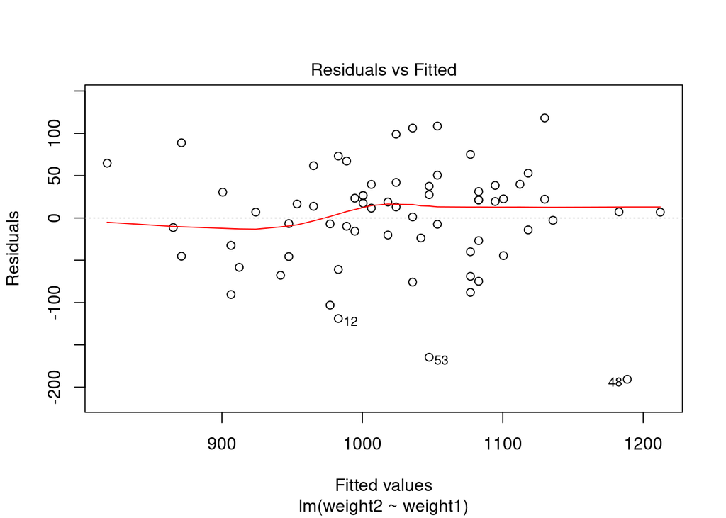

```r
plot(wtMod, 1)
```

There is no pattern. The values and more or less variance of residuals do not depend on the fitted values of `weight2`. We can conclude that residuals do have equal variance.

### 7.6.2 Residuals are normally distributed

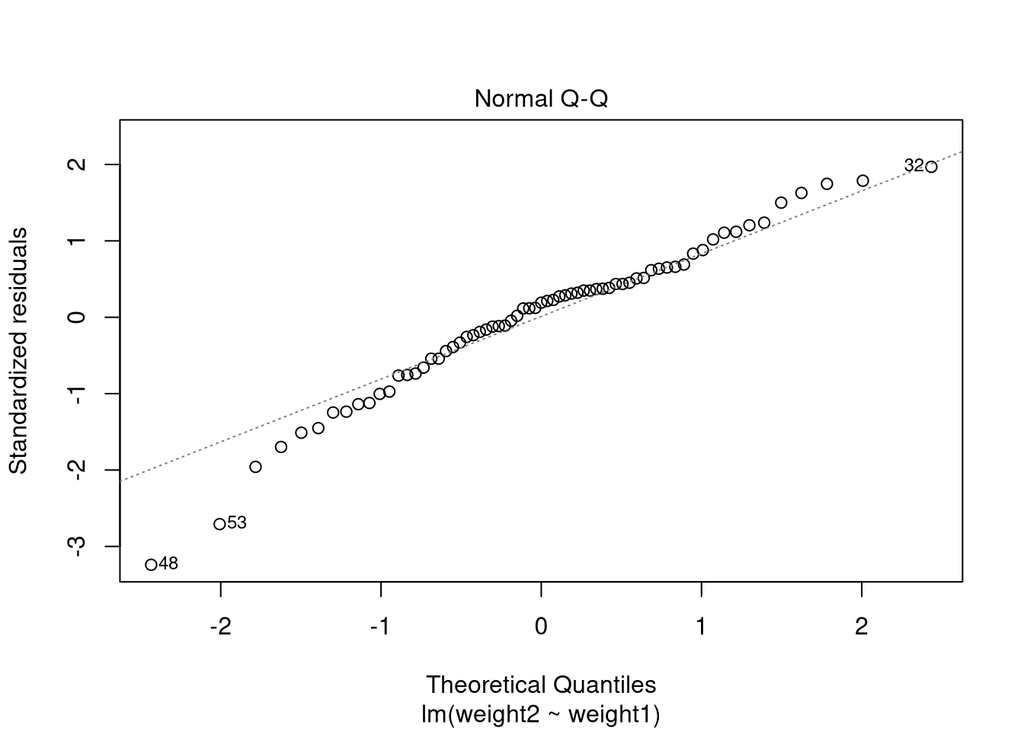

```r
plot(wtMod, 2)
```

Residuals seem to more or less follow the theoretical quantiles (the straight line). We can conclude that residuals are normally distributed.

## 7.7 Model comparison

$H_{0}:$ 2nd model has the same residual sum of squares (RSS) as 1st model.  
$H_{1}:$ 2nd model has different residual sum of squares (RSS) than 1st model.

```r
anova(wtMod, wtModFac)
```

```
## Analysis of Variance Table
##
## Model 1: weight2 ~ weight1
## Model 2: weight2 ~ weight1 + diet
##   Res.Df    RSS Df Sum of Sq      F  Pr(>F)
## 1     65 243987
## 2     63 223841  2     20146 2.8351 0.06623 .
## ---
## Signif. codes:  0 '***' 0.001 '**' 0.01 '*' 0.05 '.' 0.1 ' ' 1
```

P-value is greater than 0.05. We thus accept $H_{0}$ that 2nd model has the same residual sum of squares (RSS) as 1st model. In other words, model with `diet` added is not better in explaining the variance of `weight2` than the model without it.